# Text as data: Assignment 1

2022-10-13

## Getting and parsing texts

To start with, you are asked to retrieve *Songs of Innocence and of Experience* by William Blake from Project Gutenberg. It is located at https://www.gutenberg.org/cache/epub/1934/pg1934.txt. This is a collection of poems in two books: *Songs of Innocence* and *Songs of Experience*.

Parse this into a dataframe where each row is a line of a poem (there should be no empty lines). The following columns should describe where each line was found:

- line_number
- stanza_number
- poem_title
- book_title

```r
#we start by getting the file from where it's located
blake <- read_file("https://www.gutenberg.org/cache/epub/1934/pg1934.txt")
```

```r
#first, we find the names of the books
pattern_songs <- "([A-Z ]+)\r\n\r\n\r\n\r\n\r\nINTRODUCTION"
songs <- str_match_all(blake, pattern_songs)[[1]][,2]
songs
```

```
## [1] "SONGS OF INNOCENCE"  "SONGS OF EXPERIENCE"
```

```r
#then, we find the complete text of the books
pattern_innocence <- "(?<=SONGS OF INNOCENCE[\\r\\n]{5})([\\s\\S]*)(?=SONGS OF EXPERIENCE)"
pattern_experience <- "(?<=SONGS OF EXPERIENCE[\\r\\n]{5})([\\s\\S]*)(?=[\\r\\n]{5}+[\\*{3}])"

innocence <- str_match_all(blake, pattern_innocence)[[1]][,1]
experience <- str_match_all(blake, pattern_experience)[[1]][,1]
```

```r
#we create a data frame for the text, then create a row for each poem
blake_df_01 <- data.frame(book_title = songs, complete_text = c(innocence, experience)) %>% mutate(complete_text = strsplit(as.character(complete_text), "\r\n\r\n\r\n\r\n\r\n")) %>% unnest(complete_text)
blake_df_01
```

```
## # A tibble: 47 × 2
##    book_title         complete_text
##    <chr>              <chr>
##  1 SONGS OF INNOCENCE "\n\r\n\r\nINTRODUCTION\r\n\r\n\r\nPiping down the valley…
##  2 SONGS OF INNOCENCE "THE SHEPHERD\r\n\r\n\r\nHow sweet is the shepherd’s swee…
##  3 SONGS OF INNOCENCE "THE ECHOING GREEN\r\n\r\n\r\nThe sun does arise,\r\nAnd …
##  4 SONGS OF INNOCENCE "THE LAMB\r\n\r\n\r\nLittle lamb, who made thee?\r\nDoes …
##  5 SONGS OF INNOCENCE "\r\nTHE LITTLE BLACK BOY\r\n\r\n\r\nMy mother bore me in…
##  6 SONGS OF INNOCENCE "THE BLOSSOM\r\n\r\n\r\nMerry, merry sparrow!\r\nUnder le…
##  7 SONGS OF INNOCENCE "THE CHIMNEY-SWEEPER\r\n\r\n\r\nWhen my mother died I was…
##  8 SONGS OF INNOCENCE "THE LITTLE BOY LOST\r\n\r\n\r\n‘Father, father, where ar…
##  9 SONGS OF INNOCENCE "THE LITTLE BOY FOUND\r\n\r\n\r\nThe little boy lost in t…
## 10 SONGS OF INNOCENCE "LAUGHING SONG\r\n\r\n\r\nWhen the green woods laugh with…
## # … with 37 more rows
```

```r
#we create a column for poem titles
blake_df_01 <- blake_df_01 %>% separate(complete_text, into = c("poem_title", "stanzas"), sep = "\r\n\r\n\r\n")
blake_df_01
```

```
## # A tibble: 47 × 3
##    book_title         poem_title                 stanzas
##    <chr>              <chr>                      <chr>
##  1 SONGS OF INNOCENCE "\n\r\n\r\nINTRODUCTION"   "Piping down the valleys wild,…
##  2 SONGS OF INNOCENCE "THE SHEPHERD"             "How sweet is the shepherd’s s…
##  3 SONGS OF INNOCENCE "THE ECHOING GREEN"        "The sun does arise,\r\nAnd ma…
##  4 SONGS OF INNOCENCE "THE LAMB"                 "Little lamb, who made thee?\r…
##  5 SONGS OF INNOCENCE "\r\nTHE LITTLE BLACK BOY" "My mother bore me in the sout…
##  6 SONGS OF INNOCENCE "THE BLOSSOM"              "Merry, merry sparrow!\r\nUnde…
##  7 SONGS OF INNOCENCE "THE CHIMNEY-SWEEPER"      "When my mother died I was ver…
##  8 SONGS OF INNOCENCE "THE LITTLE BOY LOST"      "‘Father, father, where are yo…
##  9 SONGS OF INNOCENCE "THE LITTLE BOY FOUND"     "The little boy lost in the lo…
## 10 SONGS OF INNOCENCE "LAUGHING SONG"            "When the green woods laugh wi…
## # … with 37 more rows
```

```r
#then, we separate the stanzas and number them
blake_df_02 <- blake_df_01 %>% mutate(stanzas = strsplit(as.character(stanzas), "\r\n\r\n"))  %>% unnest(stanzas) %>% group_by(book_title,poem_title) %>% mutate(stanza_number = 1:n())
blake_df_02
```

```
## # A tibble: 202 × 4
## # Groups:   book_title, poem_title [47]
##    book_title         poem_title               stanzas             stanza_number
##    <chr>              <chr>                    <chr>                       <int>
##  1 SONGS OF INNOCENCE "\n\r\n\r\nINTRODUCTION" "Piping down the v…             1
##  2 SONGS OF INNOCENCE "\n\r\n\r\nINTRODUCTION" "‘Pipe a song abou…             2
##  3 SONGS OF INNOCENCE "\n\r\n\r\nINTRODUCTION" "‘Drop thy pipe, t…             3
##  4 SONGS OF INNOCENCE "\n\r\n\r\nINTRODUCTION" "‘Piper, sit thee …             4
##  5 SONGS OF INNOCENCE "\n\r\n\r\nINTRODUCTION" "And I made a rura…             5
##  6 SONGS OF INNOCENCE "THE SHEPHERD"           "How sweet is the …             1
##  7 SONGS OF INNOCENCE "THE SHEPHERD"           "For he hears the …             2
##  8 SONGS OF INNOCENCE "THE ECHOING GREEN"      "The sun does aris…             1
##  9 SONGS OF INNOCENCE "THE ECHOING GREEN"      "Old John, with wh…             2
## 10 SONGS OF INNOCENCE "THE ECHOING GREEN"      "Till the little o…             3
## # … with 192 more rows
```

```r
#similarly, we separate the lines and number them
blake_df_02 <- blake_df_02 %>% mutate(stanzas = strsplit(as.character(stanzas), "\r\n")) %>% unnest(stanzas) %>% group_by(book_title, poem_title) %>% mutate(line_number = 1:n())
blake_df_02
```

```
## # A tibble: 910 × 5
## # Groups:   book_title, poem_title [47]
##    book_title         poem_title               stanzas stanza_number line_number
##    <chr>              <chr>                    <chr>           <int>       <int>
##  1 SONGS OF INNOCENCE "\n\r\n\r\nINTRODUCTION" "Pipin…             1           1
##  2 SONGS OF INNOCENCE "\n\r\n\r\nINTRODUCTION" "    P…             1           2
##  3 SONGS OF INNOCENCE "\n\r\n\r\nINTRODUCTION" "On a …             1           3
##  4 SONGS OF INNOCENCE "\n\r\n\r\nINTRODUCTION" "    A…             1           4
##  5 SONGS OF INNOCENCE "\n\r\n\r\nINTRODUCTION" "‘Pipe…             2           5
##  6 SONGS OF INNOCENCE "\n\r\n\r\nINTRODUCTION" "    S…             2           6
##  7 SONGS OF INNOCENCE "\n\r\n\r\nINTRODUCTION" "‘Pipe…             2           7
##  8 SONGS OF INNOCENCE "\n\r\n\r\nINTRODUCTION" "    S…             2           8
##  9 SONGS OF INNOCENCE "\n\r\n\r\nINTRODUCTION" "‘Drop…             3           9
## 10 SONGS OF INNOCENCE "\n\r\n\r\nINTRODUCTION" "    S…             3          10
## # … with 900 more rows
```

```r
#then we clean the data frame
blake_df <- rename(blake_df_02, lines = stanzas)
blake_df <- blake_df[, c("lines", "book_title", "poem_title", "stanza_number", "line_number")]
blake_df$poem_title <- gsub("\n\r\n\r\n", "", blake_df$poem_title)
blake_df$poem_title <- gsub("\r\n", "", blake_df$poem_title)

#and finally, we print the clean, final version
blake_df
```

```
## # A tibble: 910 × 5
## # Groups:   book_title, poem_title [47]
##    lines                    book_title     poem_title  stanza_number line_number
##    <chr>                    <chr>          <chr>               <int>       <int>
##  1 "Piping down the valley… SONGS OF INNO… INTRODUCTI…             1           1
##  2 "    Piping songs of pl… SONGS OF INNO… INTRODUCTI…             1           2
##  3 "On a cloud I saw a chi… SONGS OF INNO… INTRODUCTI…             1           3
##  4 "    And he laughing sa… SONGS OF INNO… INTRODUCTI…             1           4
##  5 "‘Pipe a song about a L… SONGS OF INNO… INTRODUCTI…             2           5
##  6 "    So I piped with me… SONGS OF INNO… INTRODUCTI…             2           6
##  7 "‘Piper, pipe that song… SONGS OF INNO… INTRODUCTI…             2           7
##  8 "    So I piped: he wep… SONGS OF INNO… INTRODUCTI…             2           8
##  9 "‘Drop thy pipe, thy ha… SONGS OF INNO… INTRODUCTI…             3           9
## 10 "    Sing thy songs of … SONGS OF INNO… INTRODUCTI…             3          10
## # … with 900 more rows
```

## Visualising text data

- Create a histogram showing the number of lines per poem
- Create a document feature matrix treating each line as a document
- Create a separate document feature matrix treating each poem as a document
- Using one of these document feature matrices, create a plot that compares the frequency of words in each book. Comment on the features that are more or less frequent in one book than another.

```r
#we prepare the data for the histogram
hist_df <- blake_df %>% group_by(poem_title) %>% summarise(max = max(line_number, na.rm=TRUE))
hist_df
```

```
## # A tibble: 42 × 2
##    poem_title           max
##    <chr>              <int>
##  1 A CRADLE SONG         32
##  2 A DIVINE IMAGE         8
##  3 A DREAM               20
##  4 A LITTLE BOY LOST     24
##  5 A LITTLE GIRL LOST    34
##  6 A POISON TREE         16
##  7 AH, SUNFLOWER          8
##  8 EARTH’S ANSWER        25
##  9 HOLY THURSDAY         16
## 10 INFANT JOY            12
## # … with 32 more rows
```

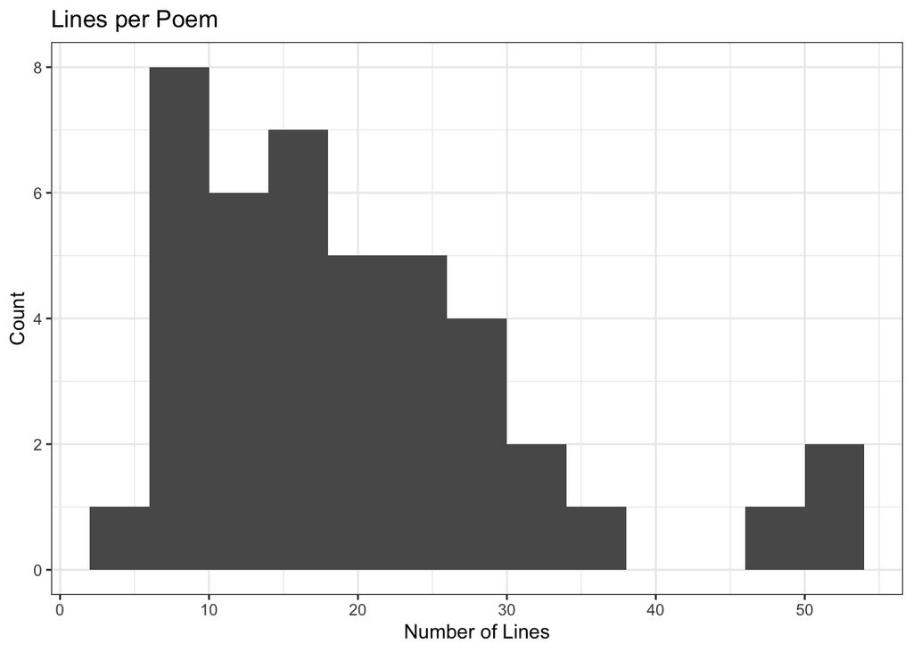

```r
#we create the histogram using ggplot
plot01 <- ggplot(hist_df, aes(x=max)) +
  geom_histogram(binwidth=4) +
  labs(title = "Lines per Poem", x = "Number of Lines", y = "Count") +
  theme_bw()
plot01
```

```r
#we create a document feature matrix, treating each line as a document
lines_matrix <- blake_df$lines %>% tokens(remove_punc=TRUE) %>% tokens_remove(pattern=stopwords("en")) %>% tokens_wordstem("english") %>% dfm()
lines_matrix
```

```
## Document-feature matrix of: 910 documents, 957 features (99.67% sparse) and 0 docvars.
##        features
## docs    pipe valley wild song pleasant glee cloud saw child laugh
##   text1    1      1    1    0        0    0     0   0     0     0
##   text2    1      0    0    1        1    1     0   0     0     0
##   text3    0      0    0    0        0    0     1   1     1     0
##   text4    0      0    0    0        0    0     0   0     0     1
##   text5    1      0    0    1        0    0     0   0     0     0
##   text6    1      0    0    0        0    0     0   0     0     0
## [ reached max_ndoc ... 904 more documents, reached max_nfeat ... 947 more features ]
```

```r
#we rearrange an earlier version of the data frame from section 1 to treat each poem as a document
blake_df_01$poem_title <- gsub("\n\r\n\r\n", "", blake_df_01$poem_title)
blake_df_01$poem_title <- gsub("\r\n", "", blake_df_01$poem_title)
blake_df_01$stanzas <- gsub("\r\n", " ", blake_df_01$stanzas)
blake_df_01
```

```
## # A tibble: 47 × 3
##    book_title         poem_title           stanzas
##    <chr>              <chr>                <chr>
##  1 SONGS OF INNOCENCE INTRODUCTION         Piping down the valleys wild,     Pi…
##  2 SONGS OF INNOCENCE THE SHEPHERD         How sweet is the shepherd’s sweet lo…
##  3 SONGS OF INNOCENCE THE ECHOING GREEN    The sun does arise, And make happy t…
##  4 SONGS OF INNOCENCE THE LAMB             Little lamb, who made thee? Does tho…
##  5 SONGS OF INNOCENCE THE LITTLE BLACK BOY My mother bore me in the southern wi…
##  6 SONGS OF INNOCENCE THE BLOSSOM          Merry, merry sparrow! Under leaves s…
##  7 SONGS OF INNOCENCE THE CHIMNEY-SWEEPER  When my mother died I was very young…
##  8 SONGS OF INNOCENCE THE LITTLE BOY LOST  ‘Father, father, where are you going…
##  9 SONGS OF INNOCENCE THE LITTLE BOY FOUND The little boy lost in the lonely fe…
## 10 SONGS OF INNOCENCE LAUGHING SONG        When the green woods laugh with the …
## # … with 37 more rows
```

```r
#we create a document feature matrix, treating each poem as a document
poem_matrix <- blake_df_01$poem_title %>% tokens(remove_punc=TRUE) %>% tokens_remove(pattern=stopwords("en")) %>% tokens_wordstem("english") %>% dfm()
poem_matrix
```

```
## Document-feature matrix of: 47 documents, 54 features (96.61% sparse) and 0 docvars.
##        features
## docs    introduction shepherd echoing green lamb little black boi blossom
##   text1            1        0       0     0    0      0     0   0       0
##   text2            0        1       0     0    0      0     0   0       0
##   text3            0        0       1     1    0      0     0   0       0
##   text4            0        0       0     0    1      0     0   0       0
##   text5            0        0       0     0    0      1     1   1       0
##   text6            0        0       0     0    0      0     0   0       1
##        features
## docs    chimney-sweeper
##   text1               0
##   text2               0
##   text3               0
##   text4               0
##   text5               0
##   text6               0
## [ reached max_ndoc ... 41 more documents, reached max_nfeat ... 44 more features ]
```

```r
#we create a freq table for all features
lines_freq <- lines_matrix %>% textstat_frequency(groups=blake_df$book_title)
lines_freq %>% head()
```

```
##   feature frequency rank docfreq               group
## 1   night        20    1      20 SONGS OF EXPERIENCE
## 2     thi        19    2      18 SONGS OF EXPERIENCE
## 3    love        17    3      16 SONGS OF EXPERIENCE
## 4    weep        16    4      15 SONGS OF EXPERIENCE
## 5   sleep        16    4      13 SONGS OF EXPERIENCE
## 6     day        13    6      13 SONGS OF EXPERIENCE
```

```r
#then, we filter by group, and create freq tables for both books' top features
in_freq <- lines_freq %>% filter(group == "SONGS OF INNOCENCE") %>% head(20)
ex_freq <- lines_freq %>% filter(group == "SONGS OF EXPERIENCE") %>% head(20)
top_freq <- bind_rows(in_freq, ex_freq)
top_freq %>% head()
```

```
##     feature frequency rank docfreq              group
## 712    thee        25    1      24 SONGS OF INNOCENCE
## 713   littl        21    2      21 SONGS OF INNOCENCE
## 714   sweet        19    3      18 SONGS OF INNOCENCE
## 715     joy        18    4      18 SONGS OF INNOCENCE
## 716    lamb        17    5      17 SONGS OF INNOCENCE
## 717     can        14    6      14 SONGS OF INNOCENCE
```

We can create 2 separate frequency table to observe how top features change:

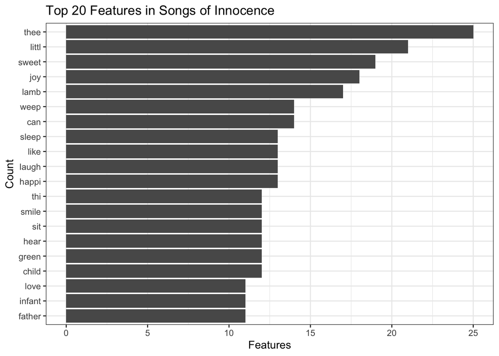

```r
#we create plots to explore both tables
plot_02 <- ggplot(in_freq, aes(y=reorder(feature, frequency), x=frequency)) +
  geom_col() +
  labs(title = "Top 20 Features in Songs of Innocence", x = "Features", y = "Count") +
  theme_bw()
plot_02
```

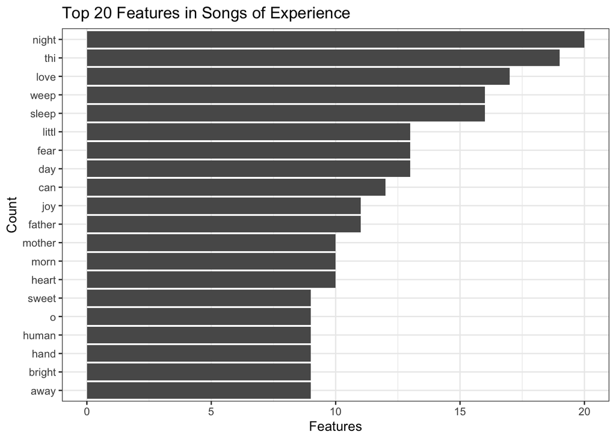

```r
plot_03 <- ggplot(ex_freq, aes(y=reorder(feature, frequency), x=frequency)) +
  geom_col() +
  labs(title = "Top 20 Features in Songs of Experience", x = "Features", y = "Count") +
  theme_bw()
plot_03
```

We observe from these top features plots that the books are thematically differ from one another. Songs of Innocence has a much more nostalgic and melancholic tone, drawing on childhood (note features such as sweet, little, lamb, child, infant, and father) and pure emotions (note features such as joy, weep, laugh, happi, and smile). On the other hand, Song of Experience has a much more darker tone (note features such as night, fear, morn, human, and away). There are 9 features that appear in both lists (thi, love, weep, sleep, littl, can, joy, father, sweet), where 4 of them appear more on Songs of Innocence (littl, joy, sweet, can), and 4 of them appear more on Songs of Experience (thi, love, weep, sleep), 1 of them appear an exact same amount (father).

## Parsing XML text data

Now we will work with German Parliamentary data, which is available in XML format [here](https://www.bundestag.de/services/opendata) for the last two parliamentary periods. Remember XML format is very like HTML format, and we can parse it using a scraper and CSS selectors. Speeches are contained in `<rede>` elements, which each contain a paragraph element describing the speaker, and paragraph elements recording what they said. Not that class selectors won’t work, because the class attribute is called “klasse”. You can use normal attribute selectors.

Choose one of the sessions, and retrieve it using R or Python. Using a scraper, get a list of all the elements. For each element, get the name of the speaker, and a single string containing everything that they said. Put this into a dataframe. Print the number of speeches, and the content of the first speech, by a politician of your choice.

```r
#first, we read the xml text data
library(rvest)
link <- read_html("https://www.bundestag.de/resource/blob/901386/2a11260627e1e60eb570abdcaf1d4c60/20045-data.xml")
link
```

```
## {html_document}
## <html>
## [1] <body><dbtplenarprotokoll vertrieb="Bundesanzeiger Verlagsgesellschaft mb ...
```

```r
#we find the relevant node set
speeches <- link %>% html_elements("rede")
speeches
```

```
## {xml_nodeset (98)}
##  [1] <rede id="ID204500100"><p klasse="redner">\r\n\t\t\t\t\t<redner id="1100 ...
##  [2] <rede id="ID204500200"><p klasse="redner">\r\n\t\t\t\t\t<redner id="1100 ...
##  [3] <rede id="ID204500300"><p klasse="redner">\r\n\t\t\t\t\t<redner id="1100 ...
##  [4] <rede id="ID204500400"><p klasse="redner">\r\n\t\t\t\t\t<redner id="1100 ...
##  [5] <rede id="ID204500500"><p klasse="redner">\r\n\t\t\t\t\t<redner id="1100 ...
##  [6] <rede id="ID204500600"><p klasse="redner">\r\n\t\t\t\t\t<redner id="1100 ...
##  [7] <rede id="ID204500700"><p klasse="redner">\r\n\t\t\t\t\t<redner id="1100 ...
##  [8] <rede id="ID204500800"><p klasse="redner">\r\n\t\t\t\t\t<redner id="1100 ...
##  [9] <rede id="ID204500900"><p klasse="redner">\r\n\t\t\t\t\t<redner id="1100 ...
## [10] <rede id="ID204501000"><p klasse="redner">\r\n\t\t\t\t\t<redner id="1100 ...
## [11] <rede id="ID204501100"><p klasse="redner">\r\n\t\t\t\t\t<redner id="1100 ...
## [12] <rede id="ID204501200"><p klasse="redner">\r\n\t\t\t\t\t<redner id="1100 ...
## [13] <rede id="ID204501300"><p klasse="redner">\r\n\t\t\t\t\t<redner id="1100 ...
## [14] <rede id="ID204501400"><p klasse="redner">\r\n\t\t\t\t\t<redner id="1100 ...
## [15] <rede id="ID204501500"><p klasse="redner">\r\n\t\t\t\t\t<redner id="1100 ...
## [16] <rede id="ID204501600"><p klasse="redner">\r\n\t\t\t\t\t<redner id="1100 ...
## [17] <rede id="ID204501700"><p klasse="redner">\r\n\t\t\t\t\t<redner id="1100 ...
## [18] <rede id="ID204501800"><p klasse="redner">\r\n\t\t\t\t\t<redner id="1100 ...
## [19] <rede id="ID204501900"><p klasse="redner">\r\n\t\t\t\t\t<redner id="1100 ...
## [20] <rede id="ID204502000"><p klasse="redner">\r\n\t\t\t\t\t<redner id="1100 ...
## ...
```

```r
#we create an empty data frame
plenaryinfo = data.frame()

#then we put each node in a loop to get the relevant info
for (speech in speeches) {

  #we get speaker name, lastname, and speech text
  speaker_name <- speech %>% html_elements("p redner name vorname") %>% html_text2()
  speaker_lastname <- speech %>% html_elements("p redner name nachname") %>% html_text2()
  speechtext <- speech %>% html_elements("p[klasse!=redner]") %>% html_text2() %>% paste(collapse = " ")

  #we put the info in the data frame
  plenary = c(speaker_name, speaker_lastname, speechtext)
  plenaryinfo = rbind(plenaryinfo, plenary)
  }

#we rename the columns appropriately
colnames(plenaryinfo)<-c("speaker_name", "speaker_lastname", "speech_text")

#and print
plenaryinfo %>% head()
```

```
##   speaker_name   speaker_lastname
## 1        Marco          Buschmann
## 2    Elisabeth Winkelmeier-Becker
## 3         Dirk              Wiese
## 4       Thomas              Seitz
## 5         Lisa               Paus
## 6        Heidi         Reichinnek
##                                                                                                                                                                                                                                                                                                          …
## 1                                                                                                                                                                                                                                                                                                        …
## 2 Frau Präsidentin! Liebe Kolleginnen und Kollegen! Sehr geehrter Herr Bundesminister, laut Koalitionsvertrag haben Sie sich vorgenommen, wissenschaftliche Evidenz und Evaluierung von Gesetzen zum Maßstab für Ihre Kriminalpolitik zu machen. Mit dem Gesetzentwurf zur Streichung von § 219a StGB wer…
## 3                                                                                                                                                                                                                                                                                                        …
## 4                                                                                                                                                                                                                                                                                                        …
## 5                                                                                                                                                                                                                                                                                                        …
## 6                                                                                                                                                                                                                                                                                                        …
```

Let’s find the number of speeches by Katrin Helling-Plahr:

```r
#we filter by last name
filter_hellingplahr <- filter(plenaryinfo, speaker_lastname == "Helling-Plahr")
filter_hellingplahr
```

```
##   speaker_name speaker_lastname
## 1       Katrin    Helling-Plahr
## 2       Katrin    Helling-Plahr
##                                                                                                                                                                                                                                                                                                          …
## 1                                                                                                                                                                                                                                                                                                        …
## 2 Sehr geehrter Herr Präsident! Meine Damen und Herren! Sterben – ehrlich gesagt, ein Thema, das mir Angst macht. Schon seit ich ein kleines Kind war, tut es das. Ich kann mir das irgendwie gar nicht vorstellen, nicht mehr da sein auf dieser Welt. Wo dann? Ich weiß nicht, wie es Ihnen geht – viel…
```

```r
#then print the number of rows to get number of speeches
filter_hellingplahr %>% nrow()
```

```
## [1] 2
```

We can get the speech of the first speaker by calling the relevant row and column:

```r
#we call on the first speech
filter_hellingplahr[1, 3]
```

```
## [1] "Sehr geehrte Frau Präsidentin! Meine Damen und Herren! Ich weiß nicht, wer von Ihnen sich selbst bereits näher mit der Frage der Abtreibung auseinandersetzen musste, und das geht mich auch nichts an. Mir ganz persönlich ist das erspart geblieben. Ich habe eine solche Notsituation in meinem n…
```

## Using regular expressions

Using a regular expression, get a list of words spoken in your parliamentary protocol that contain (in upper or lower case) the string “kohle” (coal). Show the number of occurrences of each of these words. If there are no mentions in the debate you have selected, try another protocol.

```r
#we create a pattern for "kohle" with regex
pattern_kohle <- "\b?[Kk]ohle\b?"

#then we match all strings in the speech_text column of the data frame
str_match_all(plenaryinfo, pattern_kohle)[[3]][,1]
```

```
##  [1] "Kohle" "kohle" "kohle" "kohle" "kohle" "Kohle" "kohle" "Kohle" "Kohle"
## [10] "Kohle" "Kohle" "Kohle" "Kohle" "Kohle" "Kohle" "Kohle" "kohle" "Kohle"
## [19] "Kohle" "Kohle" "Kohle" "Kohle" "Kohle"
```